# Clase 3 - Datos Abiertos de Investigación. Parte 2. Portal Datos Argentina

Albano Blas Vergara, José Rodríguez de la Fuente

Doctorado en Ciencias Sociales - Universidad de Buenos Aires

# 1. Datos abiertos APN-ARG (recursos)

## 1.1. Introducción Marco

- El portal de Datos Argentina datos.gob.ar es un sistema de información que recopila y organiza un conjunto de datos abiertos provenientes de muchas organizaciones y brinda un acceso único a los mismos.
- Un portal de datos es un sistema de catálogos conformados por datasets (conjunto de datos) y metadatos que son las características que facilitan su comprensión. Los metadatos describen como está organizada la información y la política de gestión de acceso.

## 1.2. Esquema Diagrama

- En el portal de Datos Argentina, el acceso a la información se estructura a través del sitio web https://datos.gob.ar/ en el que, a través de iconos, pestañas, buscadores se procede a la búsqueda y acceso de los datos públicos. Otro modo de acceso es a través de las APIs.
- Una **API** es una interfaz de programación de aplicaciones (del inglés *Application Programming Interface*). Esta interface, manipulada a través de códigos de programación permite consultas personalizadas del sistema que contiene los datos públicos.

## 1.2. Esquema Diagrama

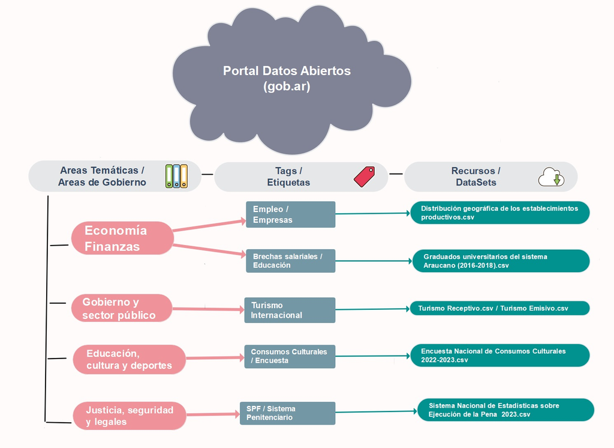

# 2. Establecimientos Productivos

## 2.1. Parámetros de búsqueda

| **Area de Gobierno:** | Economía y finanzas |
| --- | --- |
| **Organizacion:** | Secretaría de Planeamiento |
| **Tags:** | Empleo Empresas |
| **DataSet (Título)** | Distribución geográfica de los establecimientos productivos |
| **Descripción (notas):** | Datos correspondientes al Sistema Integrado Previsional Argentino y al Sistema de Alta Temprana -Simplificación Registral- de AFIP. Cuenta con información geográfica de los establecimientos productivo… |

## 2.2. Descarga de datos (archivo)

**Paso 1:** Identificar link del archivo de datos (csv) y cargarlo a la memoria del entorno. Utilizaremos la librería *read_csv* del `Tidyverse`.

```r
library(tidyverse)

geo_estab_produc <- read_csv("https://cdn.produccion.gob.ar/cdn-cep/establecimientos-productivos/distribucion_establecimientos_productivos_sexo.csv")
```

**Paso 2:** Exploración inicial del archivo de datos (variables / campos)

```
             variable      tipo
1                cuit character
2            sucursal   numeric
3                anio   numeric
4                 lat   numeric
5                 lon   numeric
6               clae6   numeric
7    in_departamentos   numeric
8        provincia_id   numeric
9             quintil   numeric
10             empleo character
11 proporcion_mujeres   numeric
```

## 2.3. Definiciones: metodología, diccionarios, códigos

[SITIO WEB DOCUMENTACION](https://cdn.produccion.gob.ar/cdn-cep/establecimientos-productivos/Metodologia_establecimiento_productivos.pdf)

## 2.4. Recursos del Dataset

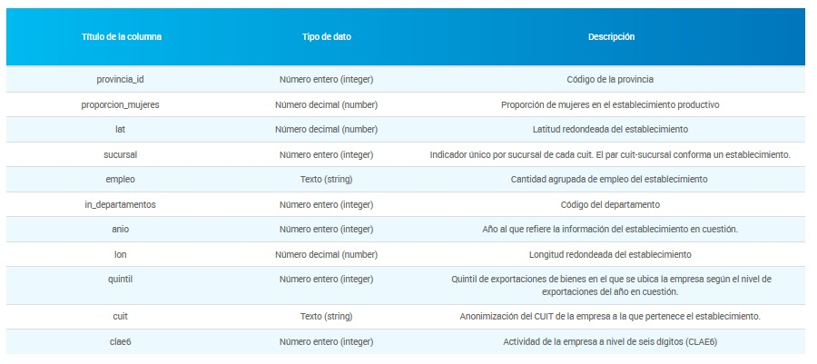

Recursos del DataSet “Establecimientos Productivos” (datos.gob.ar)

# 3. Turismo Emisivo y Receptivo

## 3.1. Parámetros de Búsqueda

| **Area de Gobierno:** | Gobierno y sector público / Población y sociedad |
| --- | --- |
| **Organizacion:** | Subsecretaría de Turismo |
| **Tags (etiquetas):** | turismo internacional |
| **DataSet (Titulo)** | Turismo Receptivo / Turismo Emisivo |
| **Descripción (notas):** | Estadísticas de turismo internacional referidas a los viajes de turistas no residentes (turismo receptivo), residentes (emisivos) y saldo entre receptivo y emisivo (balanza) a nivel país, por todos lo… |

## 3.2. Descarga de Datos (archivo)

**Paso 1:** Identificar link del archivo de datos (csv) y cargarlo a la memoria del entorno. Utilizaremos la librería *read_csv* del `Tidyverse`.

```r
turismo_receptivo <- read_delim("https://datos.yvera.gob.ar/dataset/4cbf7d4a-702a-4911-8c1e-717a45214902/resource/fdfe0ae4-4acc-4421-aa48-6149a02bc615/download/turistas-no-residentes-serie.csv", delim = ",")

turismo_emisivo <- read_delim("https://datos.yvera.gob.ar/dataset/4cbf7d4a-702a-4911-8c1e-717a45214902/resource/fd710cb7-1981-43ea-aba3-7a14c356446b/download/turistas-residentes-serie.csv", delim = ",")
```

**Paso 2:** Exploración inicial del archivo de datos (variables / campos)

```
                          variable      tipo
1                    indice_tiempo      Date
2              medio_de_transporte character
3                      pais_origen character
4 viajes_de_turistas_no_residentes   numeric
```

```
                       variable      tipo
1                 indice_tiempo      Date
2           medio_de_transporte character
3                  pais_destino character
4 viajes_de_turistas_residentes   numeric
```

## 3.3. Definiciones: metodología, diccionarios, códigos

- En este caso, se cuenta con una Ficha Técnica del recurso en el que se detalla el marco conceptual, consideraciones metodológicas y una descripción de las estadísticas de turismo internacional que se ponen a disposición en datos públicos.
- Otro aspecto relevante es que en el mismo sitio de Datos Argentina se detallan y describen los campos de información que contiene el repositorio estructurado (csv).

[SITIO WEB DOCUMENTACION](https://datos.yvera.gob.ar/dataset/4cbf7d4a-702a-4911-8c1e-717a45214902/resource/200bf770-d6f2-4847-af20-678fc0f13a0f/download/tur-inter-data.pdf)

## 3.4. Recursos del Dataset

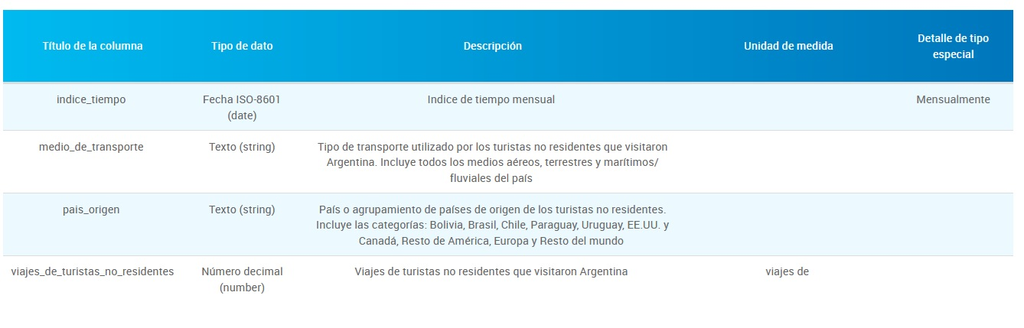

Recursos del DataSet (datos.gob.ar)

# 4. Graduados Universitarios

## 4.1. Parámetros de Búsqueda

| **Área de Gobierno:** | Economía y finanzas |
| --- | --- |
| **Organización:** | Secretaría de Planeamiento y Gestión para el Desarrollo Productivo y de la Bioeconomía |
| **Tags (etiquetas):** | Brechas Salariales / Educación |
| **Título (DataSet):** | Graduados universitarios del sistema Araucano (2016-2018) |
| **Descripción (notas):** | Base de datos que contiene, para el período 2019-2021, información sociolaboral de un conjunto de graduados de carreras universitarias de universidades argentinas entre 2016 y 2018. |

## 4.2. Descarga de datos (archivo)

**Paso 1:** Identificar link del archivo de datos (csv) y cargarlo a la memoria del entorno. Utilizaremos la librería *read_csv* del `Tidyverse`.

```r
graduados_univer <- read_delim("https://datos.produccion.gob.ar/dataset/46df1ebe-d0bb-49a1-96dd-fe9751930682/resource/afbfc04e-6130-448c-953f-ef601f3e8bda/download/base_araucano.csv", delim = ",")
```

**Paso 2:** Exploración Inicial del archivo de datos (variables / campos)

```
         variable    tipo
1              id numeric
2         rama_id numeric
3   disciplina_id numeric
4  tipo_titulo_id numeric
5      gestion_id numeric
6       genero_id numeric
7       region_id numeric
8       tamaño_id numeric
9        letra_id numeric
10        salario numeric
11           anio numeric
12     anioegreso numeric
13        anionac numeric
```

## 4.3. Definiciones: metodología, diccionarios, códigos

- En el caso de la Base Araucano, se cuenta con una Ficha sintética que detalla muy brevemente el marco teórico-metodológico.
- En este caso los campos de información que contiene el repositorio estructurado (csv) no estan en el portal de Datos Argentina, sino en el documento-ficha.
- Aquí, se cuenta con un archivo en formato excel en que se específican las codificaciones de las categorías cada una de las variables cualitativas que contiene el recurso.

[SITIO WEB DOCUMENTACION 1](https://datos.produccion.gob.ar/dataset/46df1ebe-d0bb-49a1-96dd-fe9751930682/resource/a2b14e98-9874-4b2a-b641-cdba6676de45/download/metodologia-araucano-da.pdf)

[SITIO WEB DOCUMENTACION 2](https://datos.gob.ar/dataset/produccion-graduados-universitarios-sistema-araucano-2016-2018/archivo/produccion_2976f8e2-eb30-412f-a3cf-0a445452a037)

## 4.4. Recursos del Dataset 1

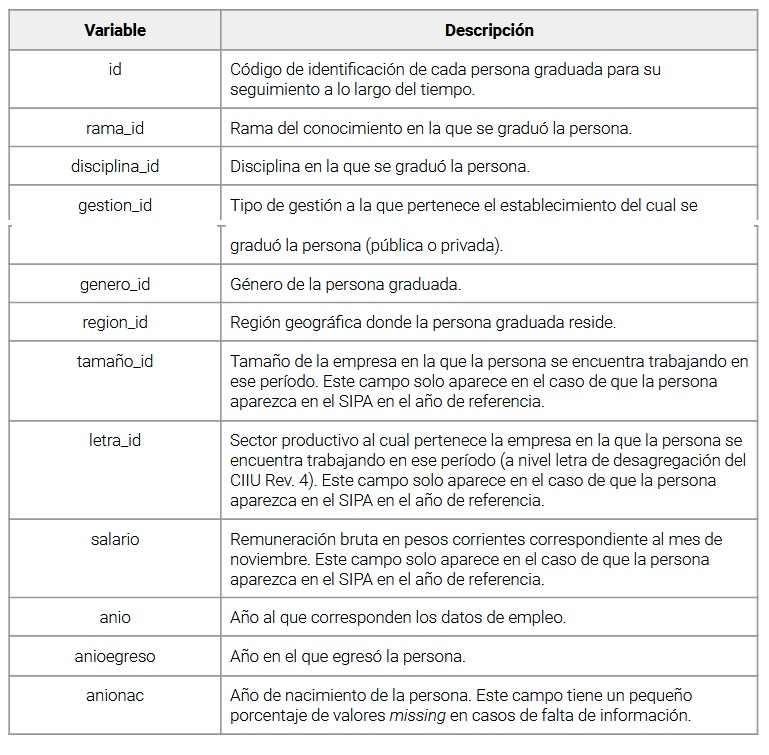

Recursos del DataSet (datos.gob.ar)

## 4.5. Recursos del Dataset 2

[figure not shown]

Recursos del DataSet (datos.gob.ar)

# 5. Encuesta Nacional de Consumos Culturales (ENCC) 2022-2023

## 5.1. Parámetros de Búsqueda

| **Área de Gobierno:** | Educación, cultura y deportes / Población y sociedad |
| --- | --- |
| **Organización:** | Secretaría de Cultura |
| **Tags (etiquetas):** | Consumos Culturales / Encuesta Nacional de Consumos Culturales |
| **Título (DataSet):** | Encuesta Nacional de Consumos Culturales 2022-2023 |
| **Descripción (notas):** | La Encuesta Nacional de Consumos Culturales busca conocer en profundidad el comportamiento de la población argentina respecto de los hábitos y consumos culturales. |

## 5.2. Descarga de datos

**Paso 1:** Identificar link del archivo de datos (csv) y cargarlo a la memoria del entorno. Utilizaremos la librería *read_csv* del `Tidyverse`.

```r
consumos_cult_22 <- read_delim("https://datos.cultura.gob.ar/dataset/251c2ac2-e670-451c-9dbf-a4212af225b5/resource/b635d1fc-2161-4901-a21d-7f93d56d99a4/download/base-datos-encc-2022-2023.csv", delim = ",")
```

**Paso 2:** Exploración inicial del archivo de datos (variables / campos). Primeras 10 variables.

```
      variable      tipo
1           id   numeric
2       region character
3    localidad character
4    provincia character
5       genero character
6         edad   numeric
7  grupos_edad character
8   niv_socioe character
9        nse_3 character
10     tamanio character
```

## 5.3. Definiciones: metodología, diccionarios, códigos

- En el caso de la ENCC, se cuenta con documento que específica marco conceptual, objetivos, metodológia la encuesta de consumo que se encuentra a disposición en datos públicos.
- Un aspecto a tomar en cuenta es que los microdatos de la encuesta presentan ponderadores (a diferencia de los recursos anteriores) y se explicitan algunas nociones sobre los mismos. Asi también, se pone a disposición el cuestionario (instrumento) aplicado en el relevamiento.
- En este recurso, los campos de información y las codificaciones que contiene el archivo estructurado (csv) no estan en el portal de Datos Argentina.

[SITIO WEB DOCUMENTO METODOLOGICO](https://datos.cultura.gob.ar/dataset/251c2ac2-e670-451c-9dbf-a4212af225b5/resource/da9823d4-543b-4efc-bb43-13d9df7344d5/download/metodologia-manual-uso-base-datos-encc-2022-2023.pdf)

[SITIO WEB CUESTIONARIO](https://datos.cultura.gob.ar/dataset/251c2ac2-e670-451c-9dbf-a4212af225b5/resource/7f0af926-e365-4e9e-bb4f-a70a3bffe416/download/cuestionario-encc-2022-2023.pdf)

## 5.4. Recursos del dataset 1

[figure not shown]

Documento Metodologico

## 5.5. Recursos del dataset 2

[figure not shown]

Cuestionario

# 6. Sistema Nacional de Estadísticas sobre Ejecución de la Pena - 2023

## 6.1. Parámetros de Búsqueda

| **Área de Gobierno:** | Justicia, seguridad y legales |
| --- | --- |
| **Organización:** | Ministerio de Justicia |
| **Tags (etiquetas):** | SPF / Sistema Penitenciario |
| **Título (DataSet):** | CENSO. Sistema Nacional de Estadísticas sobre Ejecución de la Pena - 2023 |
| **Descripción (notas):** | Información recopilada en el censo realizado sobre el total de la población detenida al día 31 de diciembre de cada año, en cada establecimiento de la República Argentina. Este recurso contiene el cen… |

## 6.2. Descarga de datos

**Paso 1:** Identificar link del archivo de datos (csv) y cargarlo a la memoria del entorno. Utilizaremos la librería *read_csv* del `Tidyverse`.

```r
library(readr)

serv_penitenciario <- read_csv("https://datos.jus.gob.ar/dataset/6c03af36-6a1d-4306-b2a8-dd39ad73afb3/resource/2fc756fc-e531-4562-8343-91f810b9fa1b/download/sneep-2023.csv")
```

**Paso 2:** Exploración inicial del archivo de datos (variables / campos). Primeras 10 variables.

```
                      variable      tipo
1                   censo_anio   numeric
2           provincia_sneep_id   numeric
3        provincia_descripcion character
4           establecimiento_id   numeric
5  establecimiento_descripcion character
6                         edad   numeric
7                    genero_id   numeric
8           genero_descripcion character
9              nacionalidad_id   numeric
10    nacionalidad_descripcion character
```

## 6.3. Definiciones: metodología, diccionarios, códigos

- A diferencia de todos los recursos anteriores presentados, este archivo de datos presenta la ficha y documentación asociada en el repositorio GitHub.
- Los campos de información y las codificaciones que contiene el archivo estructurado (csv) no estan en el portal de Datos Argentina sino en el mismo repositorio GitHub como formato plano de texto.
- Otro aspecto novedoso de este recurso (a diferencia de los anteriores) es que se presenta en el mismo portal de Datos Argentina, un sistema de visualizadores dinámicos de información. Este posibilita generar graficos interactivos y descargarlos.

[GITHUB DOCUMENTO METODOLÓGICO](https://github.com/datos-justicia-argentina/Sistema-Nacional-de-Estadisticas-sobre-Ejecucion-de-la-Pena-SNEEP/blob/master/Sistema-Nacional-de-Estadisticas-sobre-Ejecucion-de-la-Pena-SNEEP-metadata.md)

## 6.4. Recursos del dataset 1

[figure not shown]

## 6.5. Recursos del dataset 2

```
# A tibble: 26 × 3
   variable     codigo descripcion
   <chr>         <dbl> <chr>
 1 estado_civil      0 <NA>
 2 estado_civil      1 Soltero/a
 3 estado_civil      2 Casado/a
 4 estado_civil      3 Viudo/a
 5 estado_civil      4 Separado/a o divorciado/a
 6 estado_civil      5 Separado/a de hecho
 7 estado_civil      6 Concubino/a
 8 genero            1 Varón
 9 genero            2 Mujer
10 genero            3 Trans Mujer/Travesti
# ℹ 16 more rows
```